# EDA- Swire Coca Cola

Sakshi Pandey

2024-09-05

## 1. Load Libraries and Data

```r
# Load necessary libraries
library(tidyverse) # For data manipulation and visualization
library(lubridate) # For handling date and time data

# Load the CSV file (Replace the path with the correct file location)
iwc_data <- read_csv("IWC_Work_Orders_Extract.csv")

# Check the structure of the data
glimpse(iwc_data)
```

```
## Rows: 1,427,264
## Columns: 25
## $ ORDER_ID                        <dbl> 705642457, 704191697, 704466547, 70383…
## $ PLANT_ID                        <chr> "G812", "G812", "G812", "G812", "G291"…
## $ PRODUCTION_LOCATION             <chr> "ROMA", "ROMA", "ROMA", "ROMA", "MONZA…
## $ EXECUTION_START_DATE            <date> 2024-05-04, 2022-09-13, 2022-12-21, 2…
## $ EXECUTION_FINISH_DATE           <date> 2024-05-12, 2022-09-13, 2022-12-21, 2…
## $ ACTUAL_START_TIME               <time> 06:00:00, 06:00:00, 07:00:00, 06:00:0…
## $ ACTUAL_FINISH_TIME              <time> 23:04:08, 17:17:24, 07:00:00, 06:00:0…
## $ ACTUAL_WORK_IN_MINUTES          <dbl> 390, 420, 30, 60, 120, 18, 480, 30, 30…
## $ MAINTENANCE_PLAN                <chr> NA, NA, NA, NA, NA, "G291VM1437", NA, …
## $ MAINTENANCE_ITEM                <chr> NA, NA, NA, NA, NA, "0000000000040534"…
## $ MAINTENANCE_ACTIVITY_TYPE       <chr> "Unplanned", "Unplanned", "Unplanned",…
## $ ORDER_DESCRIPTION               <chr> "L2 GEARBOX LEAK (SEE ATTACHED)", "LIN…
## $ MAINTENANCE_TYPE_DESCRIPTION    <chr> "Corrective Maintenance Order", "Corre…
## $ FUNCTIONAL_LOC                  <chr> "G812-PRD-L15-L03-L030-020", "G812-PRD…
## $ FUNCTIONAL_AREA_NODE_1_MODIFIED <chr> "PRODUCTION", "PRODUCTION", "PRODUCTIO…
## $ FUNCTIONAL_AREA_NODE_2_MODIFIED <chr> "G812 PRD FILLER_ROTARY_CAN", "G812 PR…
## $ FUNCTIONAL_AREA_NODE_3_MODIFIED <chr> "G812 PRD FILLER_ROTARY_CAN LINE 3", "…
## $ FUNCTIONAL_AREA_NODE_4_MODIFIED <chr> "CONVEYOR", "CONVEYOR", "CONVEYOR", "C…
## $ FUNCTIONAL_AREA_NODE_5_MODIFIED <chr> "FULL CAN CONVEYOR", "FULL CAN CONVEYO…
## $ EQUIPMENT_ID                    <chr> "000000000300126812", "000000000300126…
## $ EQUIPMENT_DESC                  <chr> "FULL CAN CONVEYOR (FC41B)", "FULL CAN…
## $ EQUIP_CAT_DESC                  <chr> "Machines", "Machines", "Machines", "M…
## $ EQUIP_START_UP_DATE             <date> 2020-04-22, 2020-04-22, 2020-04-22, 2…
## $ EQUIP_VALID_FROM                <date> 2020-02-10, 2020-02-10, 2020-02-10, 2…
## $ EQUIP_VALID_TO                  <date> 9999-12-31, 9999-12-31, 9999-12-31, 9…
```

```r
# Summarize basic statistics
summary(iwc_data)
```

```
##     ORDER_ID           PLANT_ID         PRODUCTION_LOCATION
##  Min.   :1.000e+08   Length:1427264     Length:1427264
##  1st Qu.:4.023e+08   Class :character   Class :character
##  Median :7.044e+08   Mode  :character   Mode  :character
##  Mean   :4.561e+10
##  3rd Qu.:1.002e+09
##  Max.   :9.000e+11
##
##  EXECUTION_START_DATE EXECUTION_FINISH_DATE ACTUAL_START_TIME
##  Min.   :2013-08-19   Min.   :2016-07-25    Length:1427264
##  1st Qu.:2019-02-09   1st Qu.:2019-02-11    Class1:hms
##  Median :2020-12-09   Median :2020-12-10    Class2:difftime
##  Mean   :2020-12-20   Mean   :2020-12-21    Mode  :numeric
##  3rd Qu.:2022-12-07   3rd Qu.:2022-12-08
##  Max.   :2024-08-30   Max.   :2024-08-30
##
##  ACTUAL_FINISH_TIME ACTUAL_WORK_IN_MINUTES MAINTENANCE_PLAN
##  Length:1427264     Min.   :     0.0       Length:1427264
##  Class1:hms         1st Qu.:    12.0       Class :character
##  Class2:difftime    Median :    48.0       Mode  :character
##  Mode  :numeric     Mean   :    88.6
##                     3rd Qu.:    90.0
##                     Max.   :330184.8
##
##  MAINTENANCE_ITEM   MAINTENANCE_ACTIVITY_TYPE ORDER_DESCRIPTION
##  Length:1427264     Length:1427264            Length:1427264
##  Class :character   Class :character          Class :character
##  Mode  :character   Mode  :character          Mode  :character
##
##
##
##
##  MAINTENANCE_TYPE_DESCRIPTION FUNCTIONAL_LOC
##  Length:1427264               Length:1427264
##  Class :character             Class :character
##  Mode  :character             Mode  :character
##
##
##
##
```

[output cut: 25 more lines]

```
##  Length:1427264     Min.   :1960-01-01   Min.   :2017-02-15
##  Class :character   1st Qu.:2017-02-15   1st Qu.:2017-02-15
##  Mode  :character   Median :2017-02-15   Median :2017-03-15
##                     Mean   :2017-06-19   Mean   :2019-03-03
##                     3rd Qu.:2018-05-07   3rd Qu.:2020-08-11
##                     Max.   :2024-05-16   Max.   :2024-05-20
##                     NA's   :1347817      NA's   :1347817
##  EQUIP_VALID_TO
##  Min.   :9999-12-31
##  1st Qu.:9999-12-31
##  Median :9999-12-31
##  Mean   :9999-12-31
##  3rd Qu.:9999-12-31
##  Max.   :9999-12-31
##  NA's   :1347817
```

## 2. Data Cleaning and Exploration

```r
# Check for missing values
missing_values <- colSums(is.na(iwc_data))
missing_values
```

```
##                        ORDER_ID                        PLANT_ID
##                               0                               0
##             PRODUCTION_LOCATION            EXECUTION_START_DATE
##                               0                               0
##           EXECUTION_FINISH_DATE               ACTUAL_START_TIME
##                               0                               0
##              ACTUAL_FINISH_TIME          ACTUAL_WORK_IN_MINUTES
##                               0                               0
##                MAINTENANCE_PLAN                MAINTENANCE_ITEM
##                         1274670                         1274670
##       MAINTENANCE_ACTIVITY_TYPE               ORDER_DESCRIPTION
##                               0                         1135497
##    MAINTENANCE_TYPE_DESCRIPTION                  FUNCTIONAL_LOC
##                         1135469                         1135482
## FUNCTIONAL_AREA_NODE_1_MODIFIED FUNCTIONAL_AREA_NODE_2_MODIFIED
##                         1137147                         1144857
## FUNCTIONAL_AREA_NODE_3_MODIFIED FUNCTIONAL_AREA_NODE_4_MODIFIED
##                         1168573                         1189691
## FUNCTIONAL_AREA_NODE_5_MODIFIED                    EQUIPMENT_ID
##                         1425084                         1135469
##                  EQUIPMENT_DESC                  EQUIP_CAT_DESC
##                         1347817                         1347817
##             EQUIP_START_UP_DATE                EQUIP_VALID_FROM
##                         1347817                         1347817
##                  EQUIP_VALID_TO
##                         1347817
```

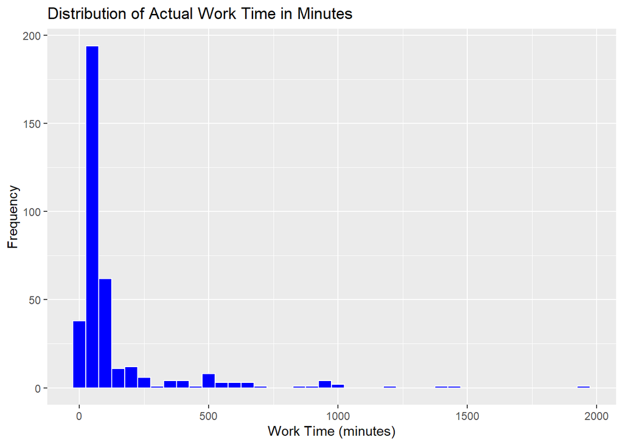

```r
# Handle missing data (e.g., removing or imputing)
# You can decide to remove rows with many missing values or impute them based on context
iwc_data_clean <- iwc_data %>% drop_na() # This drops rows with any missing values

# Convert date columns to date format for further analysis
iwc_data_clean <- iwc_data_clean %>%
  mutate(
    EXECUTION_START_DATE = ymd(EXECUTION_START_DATE),
    EXECUTION_FINISH_DATE = ymd(EXECUTION_FINISH_DATE),
    ACTUAL_START_TIME = hms(ACTUAL_START_TIME),
    ACTUAL_FINISH_TIME = hms(ACTUAL_FINISH_TIME)
  )

# Basic visualizations to understand the downtime trends
# Histogram of actual work time
ggplot(iwc_data_clean, aes(x = ACTUAL_WORK_IN_MINUTES)) +
  geom_histogram(binwidth = 50, fill = "blue", color = "white") +
  labs(title = "Distribution of Actual Work Time in Minutes", x = "Work Time (minutes)", y = "Frequency")
```

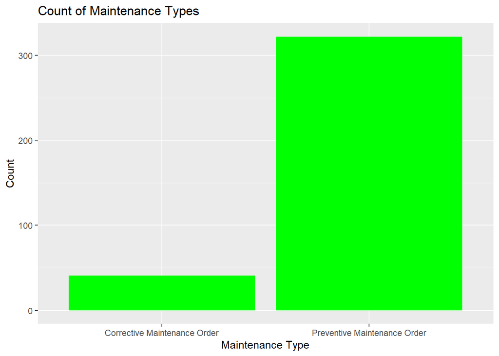

```r
# Bar plot of maintenance types
ggplot(iwc_data_clean, aes(x = MAINTENANCE_TYPE_DESCRIPTION)) +
  geom_bar(fill = "green") +
  labs(title = "Count of Maintenance Types", x = "Maintenance Type", y = "Count")
```

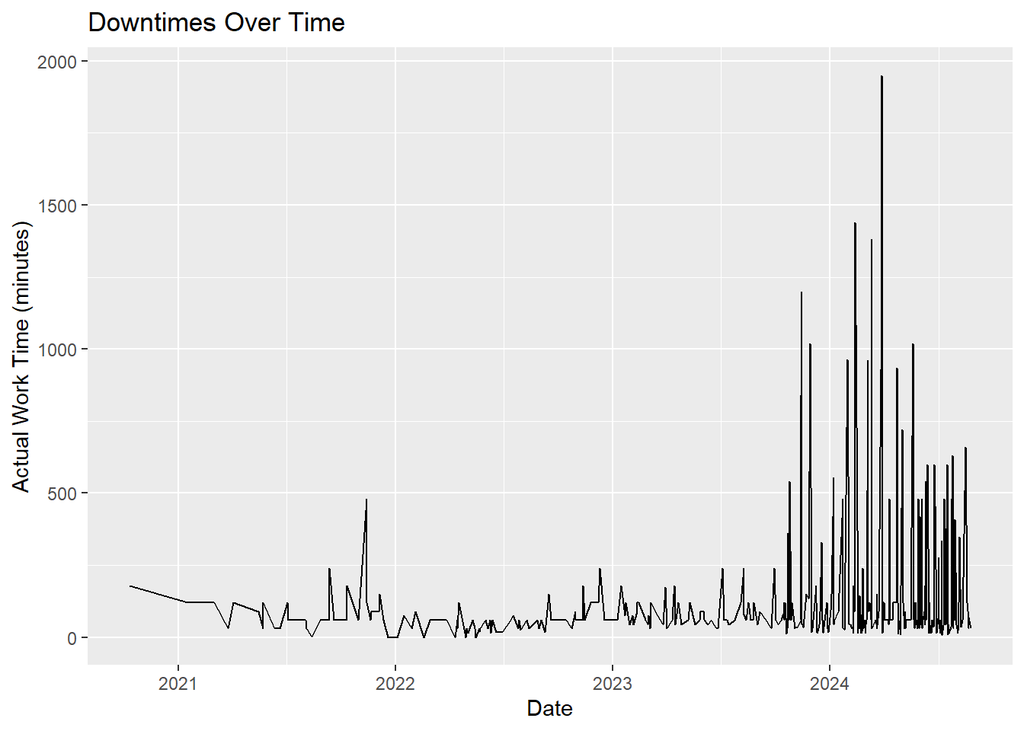

```r
# Time series plot of downtimes by date
ggplot(iwc_data_clean, aes(x = EXECUTION_START_DATE, y = ACTUAL_WORK_IN_MINUTES)) +
  geom_line() +
  labs(title = "Downtimes Over Time", x = "Date", y = "Actual Work Time (minutes)")
```

## 3. Exploratory Data Analysis (EDA)

### 3.1. Step 1: Understanding the Data Structure

First, we will take a closer look at the structure of the data, especially focusing on key variables related to downtime and machine performance

```r
# Check the structure again for reference
str(iwc_data_clean)
```

```
## tibble [363 × 25] (S3: tbl_df/tbl/data.frame)
##  $ ORDER_ID                       : num [1:363] 7.06e+08 7.06e+08 7.06e+08 7.06e+08 7.06e+08 ...
##  $ PLANT_ID                       : chr [1:363] "G291" "G291" "G291" "G291" ...
##  $ PRODUCTION_LOCATION            : chr [1:363] "MONZA" "MONZA" "MONZA" "MONZA" ...
##  $ EXECUTION_START_DATE           : Date[1:363], format: "2024-05-22" "2024-07-11" ...
##  $ EXECUTION_FINISH_DATE          : Date[1:363], format: "2024-05-22" "2024-07-11" ...
##  $ ACTUAL_START_TIME              :Formal class 'Period' [package "lubridate"] with 6 slots
##   .. ..@ .Data : num [1:363] 19 0 0 45 0 0 0 0 36 0 ...
##   .. ..@ year  : num [1:363] 0 0 0 0 0 0 0 0 0 0 ...
##   .. ..@ month : num [1:363] 0 0 0 0 0 0 0 0 0 0 ...
##   .. ..@ day   : num [1:363] 0 0 0 0 0 0 0 0 0 0 ...
##   .. ..@ hour  : num [1:363] 19 7 7 20 7 7 6 6 2 7 ...
##   .. ..@ minute: num [1:363] 3 0 0 24 0 0 0 0 56 0 ...
##  $ ACTUAL_FINISH_TIME             :Formal class 'Period' [package "lubridate"] with 6 slots
##   .. ..@ .Data : num [1:363] 19 0 0 45 0 0 0 46 0 0 ...
##   .. ..@ year  : num [1:363] 0 0 0 0 0 0 0 0 0 0 ...
##   .. ..@ month : num [1:363] 0 0 0 0 0 0 0 0 0 0 ...
##   .. ..@ day   : num [1:363] 0 0 0 0 0 0 0 0 0 0 ...
##   .. ..@ hour  : num [1:363] 21 7 7 22 7 7 6 14 7 7 ...
##   .. ..@ minute: num [1:363] 3 0 0 24 0 0 0 33 0 0 ...
##  $ ACTUAL_WORK_IN_MINUTES         : num [1:363] 120 60 60 120 30 60 60 180 120 120 ...
##  $ MAINTENANCE_PLAN               : chr [1:363] "G29112408" "G29112408" "G29112502" "G29112502" ...
##  $ MAINTENANCE_ITEM               : chr [1:363] "0000000000039866" "0000000000039866" "0000000000039876" "0000000000039876" ...
##  $ MAINTENANCE_ACTIVITY_TYPE      : chr [1:363] "Planned" "Planned" "Planned" "Planned" ...
##  $ ORDER_DESCRIPTION              : chr [1:363] "Mech_strl02_run_1939_99" "MECH_STRL02_RUN_1939_99" "REFRIG_STRL02_CHEMICAL_RUN_1870_99" "Refrig_Strl02_Chemical_Run_1870_99" ...
##  $ MAINTENANCE_TYPE_DESCRIPTION   : chr [1:363] "Preventive Maintenance Order" "Preventive Maintenance Order" "Preventive Maintenance Order" "Preventive Maintenance Order" ...
##  $ FUNCTIONAL_LOC                 : chr [1:363] "G291-PRD-L30-L03-L170-INS" "G291-PRD-L30-L03-L170-INS" "G291-PRD-L30-L03-L170-INS" "G291-PRD-L30-L03-L170-INS" ...
##  $ FUNCTIONAL_AREA_NODE_1_MODIFIED: chr [1:363] "MONZA PRODUCTION" "MONZA PRODUCTION" "MONZA PRODUCTION" "MONZA PRODUCTION" ...
##  $ FUNCTIONAL_AREA_NODE_2_MODIFIED: chr [1:363] "BTL_PET_LINE" "BTL_PET_LINE" "BTL_PET_LINE" "BTL_PET_LINE" ...
##  $ FUNCTIONAL_AREA_NODE_3_MODIFIED: chr [1:363] "LINE #3 - FILLER_ROT_BTL_PET" "LINE #3 - FILLER_ROT_BTL_PET" "LINE #3 - FILLER_ROT_BTL_PET" "LINE #3 - FILLER_ROT_BTL_PET" ...
##  $ FUNCTIONAL_AREA_NODE_4_MODIFIED: chr [1:363] "WARMER_COOLER" "WARMER_COOLER" "WARMER_COOLER" "WARMER_COOLER" ...
##  $ FUNCTIONAL_AREA_NODE_5_MODIFIED: chr [1:363] "EVANS COOLING TUNNEL L3, INSIDE BUILDING" "EVANS COOLING TUNNEL L3, INSIDE BUILDING" "EVANS COOLING TUNNEL L3, INSIDE BUILDING" "EVANS COOLING TUNNEL L3, INSIDE BUILDING" ...
##  $ EQUIPMENT_ID                   : chr [1:363] "000000000300001437" "000000000300001437" "000000000300001437" "000000000300001437" ...
##  $ EQUIPMENT_DESC                 : chr [1:363] "L3 COND_EVAP_COOLING_TOWER_BTL" "L3 COND_EVAP_COOLING_TOWER_BTL" "L3 COND_EVAP_COOLING_TOWER_BTL" "L3 COND_EVAP_COOLING_TOWER_BTL" ...
##  $ EQUIP_CAT_DESC                 : chr [1:363] "Machines" "Machines" "Machines" "Machines" ...
##  $ EQUIP_START_UP_DATE            : Date[1:363], format: "2017-02-15" "2017-02-15" ...
##  $ EQUIP_VALID_FROM               : Date[1:363], format: "2023-12-16" "2023-12-16" ...
##  $ EQUIP_VALID_TO                 : Date[1:363], format: "9999-12-31" "9999-12-31" ...
```

```r
# Check for unique values in categorical variables
unique(iwc_data_clean$PLANT_ID)
```

```
## [1] "G291" "G811" "G812"
```

```r
unique(iwc_data_clean$MAINTENANCE_TYPE_DESCRIPTION)
```

```
## [1] "Preventive Maintenance Order" "Corrective Maintenance Order"
```

```r
unique(iwc_data_clean$ORDER_DESCRIPTION)
```

```
##  [1] "Mech_strl02_run_1939_99"
##  [2] "MECH_STRL02_RUN_1939_99"
##  [3] "REFRIG_STRL02_CHEMICAL_RUN_1870_99"
##  [4] "Refrig_Strl02_Chemical_Run_1870_99"
##  [5] "REFRIG_STRL02_COND_DOWN_2239_99"
##  [6] "MONTHLY TABLE TOP MAT CHECK"
##  [7] "QUARTERLY VACUUM DECLINE BELT CHANGE"
##  [8] "6M:L3 COMBINER BELT INSPECTION"
##  [9] "1W:L3 CONVEYOR MAINTENANCE"
## [10] "1W:L1 AIR CONVEYOR MAINTENANCE"
## [11] "PACKER CASE MEAD L4 FOR MECH WHILE OPERA"
## [12] "STRL02_MECH_1250SX_FEED_2493_99"
## [13] "LINE SUPPORT DAILY - PACKER"
## [14] "PACKER CASE MEAD L4 FOR LUB WHILE SHUTDO"
## [15] "STRL02_MECH_1250SX_LUB_2501_99"
```

[output cut: 22 more lines]

```r
# Summarize downtime by plant
plant_summary <- iwc_data_clean %>%
  group_by(PLANT_ID) %>%
  summarize(
    total_downtime = sum(ACTUAL_WORK_IN_MINUTES, na.rm = TRUE),
    avg_downtime = mean(ACTUAL_WORK_IN_MINUTES, na.rm = TRUE),
    num_orders = n()
  )

# View the summary of downtime per plant
print(plant_summary)
```

```
## # A tibble: 3 × 4
##   PLANT_ID total_downtime avg_downtime num_orders
##   <chr>             <dbl>        <dbl>      <int>
## 1 G291             32302.        238.         136
## 2 G811              6874.         73.1         94
## 3 G812             10039.         75.5        133
```

### 3.2. Step 2: Visualizing Key Patterns

We’ll now visualize some of the key relationships in the data. The boxplot helps identify how different maintenance types impact the downtime.

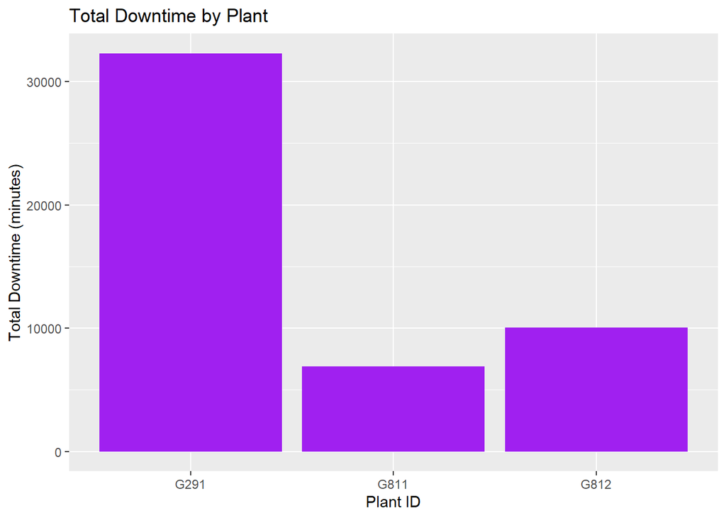

```r
# Visualize downtime per plant
ggplot(plant_summary, aes(x = PLANT_ID, y = total_downtime)) +
  geom_col(fill = "purple") +
  labs(title = "Total Downtime by Plant", x = "Plant ID", y = "Total Downtime (minutes)")
```

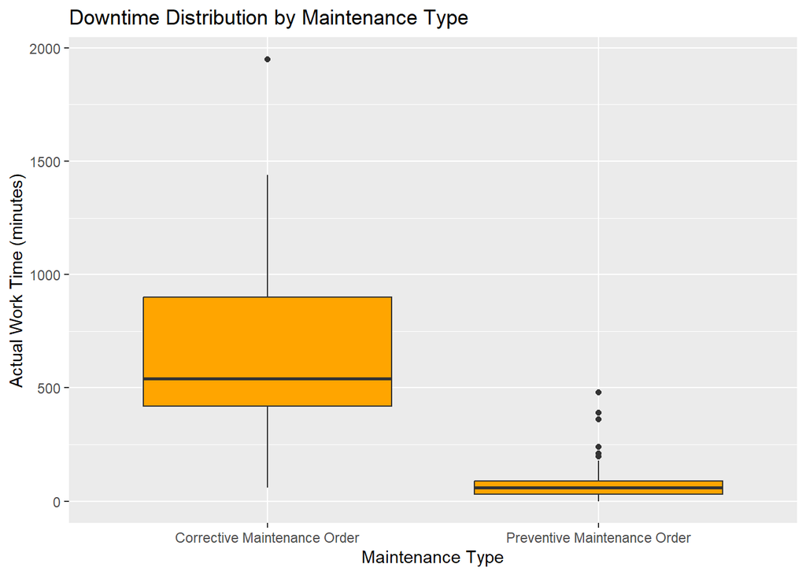

```r
# Visualize downtime distribution across different maintenance types
ggplot(iwc_data_clean, aes(x = MAINTENANCE_TYPE_DESCRIPTION, y = ACTUAL_WORK_IN_MINUTES)) +
  geom_boxplot(fill = "orange") +
  labs(title = "Downtime Distribution by Maintenance Type", x = "Maintenance Type", y = "Actual Work Time (minutes)")
```

### 3.3. Step 3: Time Series Analysis of Downtime

We can also explore how downtimes vary over time. This time series plot will help us understand if there are any trends or seasonality in machine downtimes.

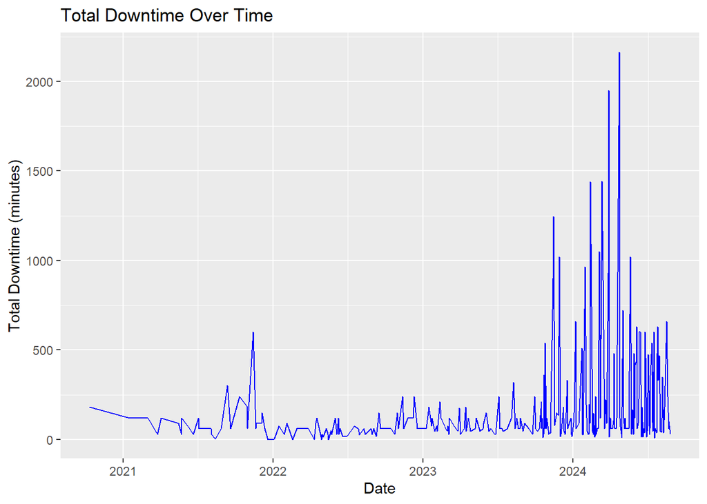

```r
# Group data by date and summarize downtime
time_series <- iwc_data_clean %>%
  group_by(EXECUTION_START_DATE) %>%
  summarize(total_downtime = sum(ACTUAL_WORK_IN_MINUTES, na.rm = TRUE))

# Plot downtime over time
ggplot(time_series, aes(x = EXECUTION_START_DATE, y = total_downtime)) +
  geom_line(color = "blue") +
  labs(title = "Total Downtime Over Time", x = "Date", y = "Total Downtime (minutes)")
```

### 3.4. Step 4: Correlation Analysis

We will now check for correlations between numerical variables (like actual work time, plant ID, etc.) to see if any relationships stand out. While plant ID is categorical, R will treat it as a numerical factor in this case, and we can check if any relationships between plant and downtime exist.

```r
# Convert PLANT_ID to numeric if needed
iwc_data_clean <- iwc_data_clean %>%
  mutate(PLANT_ID = as.numeric(as.factor(PLANT_ID)))  # Convert PLANT_ID to numeric

# Select numerical columns
numerical_cols <- iwc_data_clean %>%
  select(ACTUAL_WORK_IN_MINUTES, PLANT_ID)

# Check for missing values
missing_values_numerical <- colSums(is.na(numerical_cols))
print("Missing values in numerical columns:")
```

```
## [1] "Missing values in numerical columns:"
```

```r
print(missing_values_numerical)
```

```
## ACTUAL_WORK_IN_MINUTES               PLANT_ID
##                      0                      0
```

```r
# Remove rows with missing values
numerical_cols_clean <- na.omit(numerical_cols)

# Compute the correlation matrix
cor_matrix <- cor(numerical_cols_clean)
print("Correlation matrix:")
```

```
## [1] "Correlation matrix:"
```

```r
print(cor_matrix)
```

```
##                        ACTUAL_WORK_IN_MINUTES   PLANT_ID
## ACTUAL_WORK_IN_MINUTES              1.0000000 -0.3057383
## PLANT_ID                           -0.3057383  1.0000000
```

### 3.5. Step 5: Handling Missing Data

Let’s address any missing values in the data and decide how to deal with them (either remove or impute them).

```r
# Check again for missing values
missing_values <- colSums(is.na(iwc_data_clean))
print(missing_values)
```

```
##                        ORDER_ID                        PLANT_ID
##                               0                               0
##             PRODUCTION_LOCATION            EXECUTION_START_DATE
##                               0                               0
##           EXECUTION_FINISH_DATE               ACTUAL_START_TIME
##                               0                               0
##              ACTUAL_FINISH_TIME          ACTUAL_WORK_IN_MINUTES
##                               0                               0
##                MAINTENANCE_PLAN                MAINTENANCE_ITEM
##                               0                               0
##       MAINTENANCE_ACTIVITY_TYPE               ORDER_DESCRIPTION
##                               0                               0
##    MAINTENANCE_TYPE_DESCRIPTION                  FUNCTIONAL_LOC
##                               0                               0
## FUNCTIONAL_AREA_NODE_1_MODIFIED FUNCTIONAL_AREA_NODE_2_MODIFIED
##                               0                               0
## FUNCTIONAL_AREA_NODE_3_MODIFIED FUNCTIONAL_AREA_NODE_4_MODIFIED
##                               0                               0
## FUNCTIONAL_AREA_NODE_5_MODIFIED                    EQUIPMENT_ID
##                               0                               0
##                  EQUIPMENT_DESC                  EQUIP_CAT_DESC
##                               0                               0
##             EQUIP_START_UP_DATE                EQUIP_VALID_FROM
##                               0                               0
##                  EQUIP_VALID_TO
##                               0
```

```r
# We can choose to remove rows with too many missing values or impute them
# For this step, let's remove rows where ACTUAL_WORK_IN_MINUTES is missing, as it's a key variable
iwc_data_clean <- iwc_data_clean %>% filter(!is.na(ACTUAL_WORK_IN_MINUTES))

# Confirm that missing values are handled
sum(is.na(iwc_data_clean$ACTUAL_WORK_IN_MINUTES))
```

```
## [1] 0
```

### 3.7. Step 7: Preparing Data for Modeling

Before proceeding to the modeling phase, we will prepare the dataset by creating additional features, such as:

1. Categorical encoding: Convert categorical variables (e.g., MAINTENANCE_TYPE_DESCRIPTION, PLANT_ID) into numerical values.
2. Time features: Extract features like day of the week, month, etc., from the timestamp columns.
3. Lag features: Create lag variables to see if previous downtimes can help predict future ones.

```r
# Convert categorical variables into factors
iwc_data_clean <- iwc_data_clean %>%
  mutate(
    PLANT_ID = as.factor(PLANT_ID),
    MAINTENANCE_TYPE_DESCRIPTION = as.factor(MAINTENANCE_TYPE_DESCRIPTION)
  )

# Create new time-based features
iwc_data_clean <- iwc_data_clean %>%
  mutate(
    weekday = wday(EXECUTION_START_DATE, label = TRUE),
    month = month(EXECUTION_START_DATE, label = TRUE)
  )

# Create lag features (e.g., previous downtime)
iwc_data_clean <- iwc_data_clean %>%
  arrange(EXECUTION_START_DATE) %>%
  group_by(PLANT_ID) %>%
  mutate(lag_downtime = lag(ACTUAL_WORK_IN_MINUTES, 1, order_by = EXECUTION_START_DATE))

# View the updated dataset
head(iwc_data_clean)
```

```
## # A tibble: 6 × 28
## # Groups:   PLANT_ID [1]
##    ORDER_ID PLANT_ID PRODUCTION_LOCATION EXECUTION_START_DATE
##       <dbl> <fct>    <chr>               <date>
## 1 702453622 2        MONACO              2020-10-11
## 2 702656372 2        MONACO              2021-01-17
## 3 702720492 2        MONACO              2021-03-02
## 4 702808369 2        MONACO              2021-03-26
## 5 702852406 2        MONACO              2021-04-03
## 6 702934639 2        MONACO              2021-05-16
## # ℹ 24 more variables: EXECUTION_FINISH_DATE <date>,
## #   ACTUAL_START_TIME <Period>, ACTUAL_FINISH_TIME <Period>,
## #   ACTUAL_WORK_IN_MINUTES <dbl>, MAINTENANCE_PLAN <chr>,
## #   MAINTENANCE_ITEM <chr>, MAINTENANCE_ACTIVITY_TYPE <chr>,
## #   ORDER_DESCRIPTION <chr>, MAINTENANCE_TYPE_DESCRIPTION <fct>,
## #   FUNCTIONAL_LOC <chr>, FUNCTIONAL_AREA_NODE_1_MODIFIED <chr>,
## #   FUNCTIONAL_AREA_NODE_2_MODIFIED <chr>, …
```